# Assignment

Tarun B T

2025-04-14

Loading Required Libraries

```r
library(cluster)
```

```r
library(ggplot2)
library(dplyr)
library(fpc)
library(dbscan)
library(factoextra)
# Loading Dataset
wine_data <- read.csv("C:\\Users\\Tarun\\OneDrive\\Desktop\\R program\\6th_Assignment\\Wine-clustering-HC.csv")

# Remove categorical variables before clustering
wine_numeric <- wine_data %>% select(-c(Alcohol_Level, Ash_Content, Color_Intensity_Group))

# Normalize the data
wine_scaled <- scale(wine_numeric)
```

## **Q1-A: Perform Hierarchical Clustering (AGNES & DIANA)**

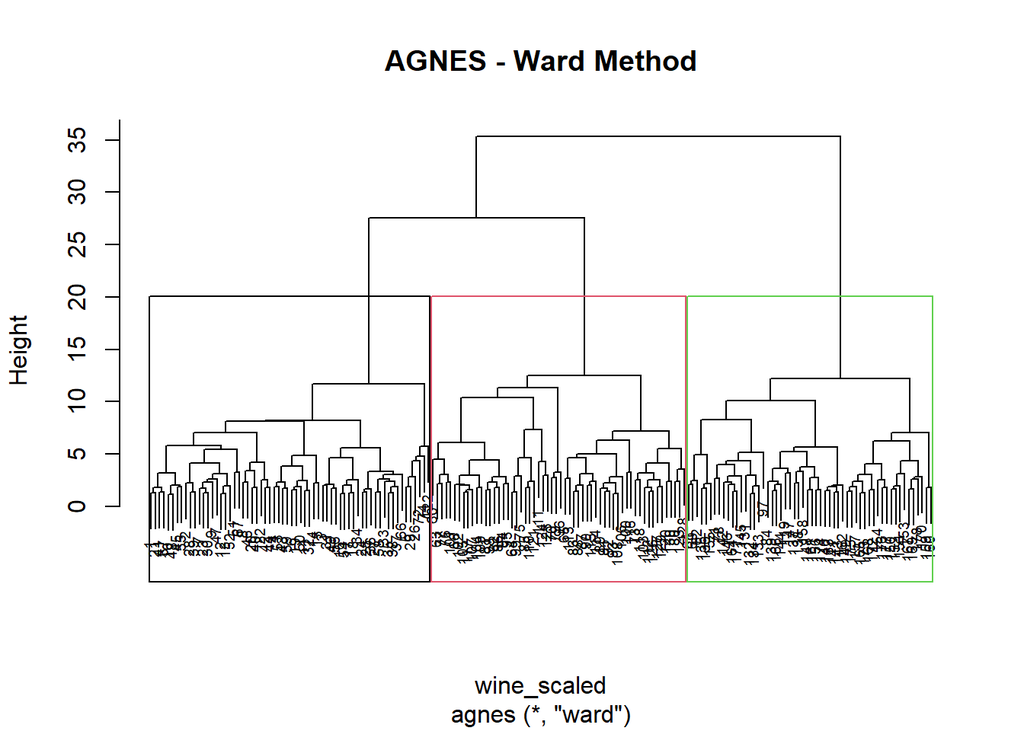

```r
# AGNES (Agglomerative Nesting)
agnes_single <- agnes(wine_scaled, method = "single")
agnes_complete <- agnes(wine_scaled, method = "complete")
agnes_ward <- agnes(wine_scaled, method = "ward")
agnes_average <- agnes(wine_scaled, method = "average")

# DIANA (Divisive Analysis)
diana_clustering <- diana(wine_scaled)

# Plot Dendrograms
pltree(agnes_ward, main="AGNES - Ward Method", cex=0.6)
rect.hclust(as.hclust(agnes_ward),k=3,border=1:3)
```

DIANA Clustering

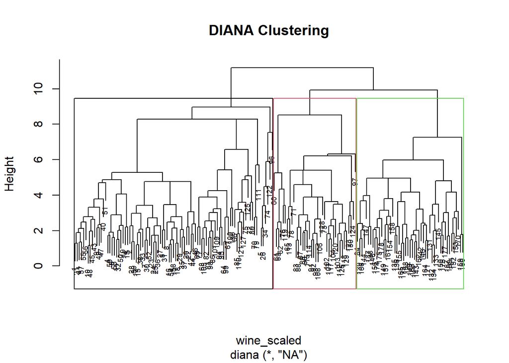

```r
pltree(diana_clustering, main="DIANA Clustering", cex=0.6)
rect.hclust(as.hclust(diana_clustering),k=3,border=1:3)
```

## **Q1-B: Compare Agglomerative and Divisive Coefficients**

```r
agnes_ac <- agnes_ward$ac
diana_dc <- diana_clustering$dc

cat("Agglomerative Coefficient (AGNES - Ward):", agnes_ac, "\n")
```

```
## Agglomerative Coefficient (AGNES - Ward): 0.9419172
```

```r
cat("Divisive Coefficient (DIANA):", diana_dc, "\n")
```

```
## Divisive Coefficient (DIANA): 0.8000096
```

```r
if (agnes_ac > diana_dc) {
  cat("AGNES provides a more cohesive clustering structure based on the coefficient.\n")
} else {
  cat("DIANA provides a more cohesive clustering structure based on the coefficient.\n")
}
```

```
## AGNES provides a more cohesive clustering structure based on the coefficient.
```

## **Q2-A: Compute Median Values for Categorical Variables**

```r
median_alcohol <- wine_data %>% group_by(Alcohol_Level) %>% summarise(Median_Alcohol = median(Alcohol, na.rm = TRUE)) # Median Alcohol by Alcohol_Level


median_ash <- wine_data %>% group_by(Ash_Content) %>% summarise(Median_Ash = median(Ash, na.rm = TRUE)) # Median Ash by Ash_Content

median_color <- wine_data %>% group_by(Color_Intensity_Group) %>% summarise(Median_Color_Intensity = median(Color_Intensity, na.rm = TRUE)) # Median Color Intensity by Color_Intensity_Group

# Display results
median_alcohol
```

```
## # A tibble: 3 × 2
##   Alcohol_Level Median_Alcohol
##   <chr>                  <dbl>
## 1 High                    13.9
## 2 Low                     12.1
## 3 Medium                  13.0
```

```r
median_ash
```

```
## # A tibble: 3 × 2
##   Ash_Content Median_Ash
##   <chr>            <dbl>
## 1 High              2.70
## 2 Low               2.17
## 3 Moderate          2.4
```

```r
median_color
```

```
## # A tibble: 3 × 2
##   Color_Intensity_Group Median_Color_Intensity
##   <chr>                                  <dbl>
## 1 Dark                                    7.65
## 2 Light                                   2.9
## 3 Moderate                                5.04
```

## **Q2-B: Visualize Median Values with Bar Plots**

Bar Plots of Median Values

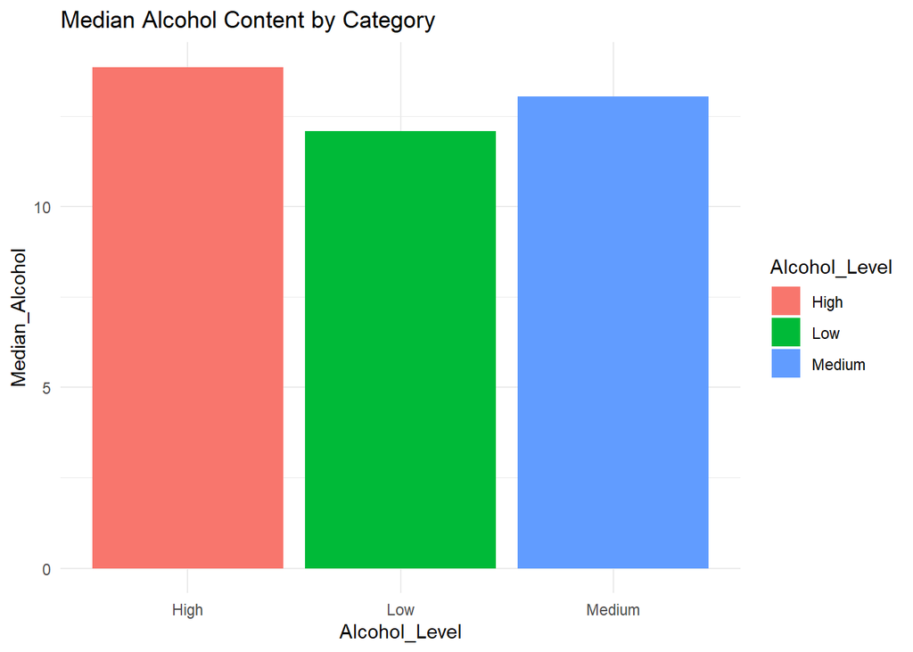

```r
ggplot(median_alcohol, aes(x = Alcohol_Level, y = Median_Alcohol, fill = Alcohol_Level)) +
  geom_bar(stat = "identity") +
  theme_minimal() +
  ggtitle("Median Alcohol Content by Category")
```

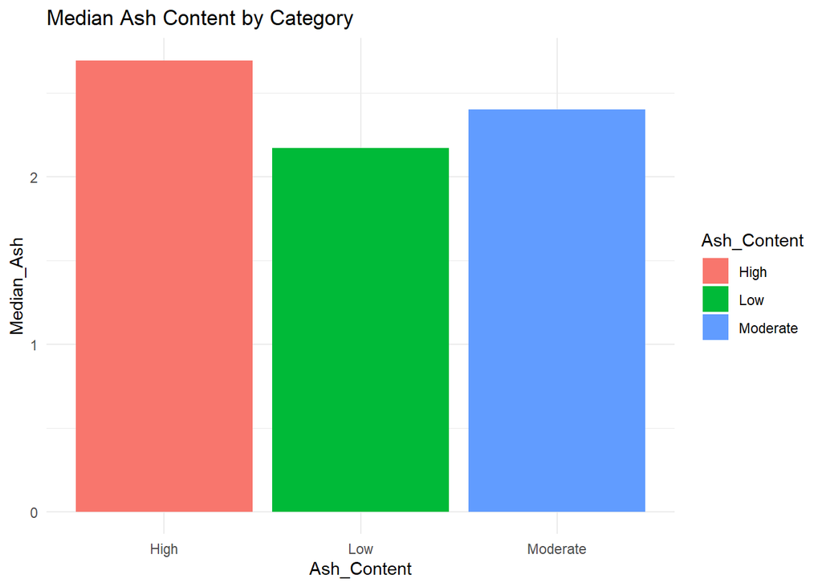

```r
ggplot(median_ash, aes(x = Ash_Content, y = Median_Ash, fill = Ash_Content)) +
  geom_bar(stat = "identity") +
  theme_minimal() +
  ggtitle("Median Ash Content by Category")
```

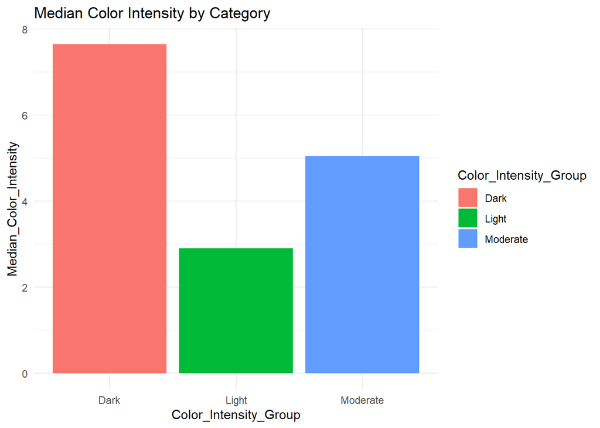

```r
ggplot(median_color, aes(x = Color_Intensity_Group, y = Median_Color_Intensity, fill = Color_Intensity_Group)) +
  geom_bar(stat = "identity") +
  theme_minimal() +
  ggtitle("Median Color Intensity by Category")
```

## **Q2-C: Interpretation of the Bar Plots**

- Higher alcohol content wines tend to have richer flavors. Wines in the ‘High’ alcohol level category (above 13.5%) show higher median alcohol percentages, suggesting fuller body, increased warmth, and complexity in flavor due to higher ethanol levels. This can influence mouthfeel and perceived sweetness.
- Ash content categories show a balanced distribution across wines. The median ash values remain fairly stable across ‘Low’, ‘Moderate’, and ‘High’ categories, indicating that ash (inorganic residue) does not drastically differ among samples. However, wines in the ‘High’ ash content group may have slightly enhanced mineral tones.
- Darker wines have higher color intensity, indicating richness and aging potential. The ‘Dark’ category exhibits significantly higher median color intensity, which often correlates with greater phenolic content, fuller flavor, and potential for aging. These wines may also have deeper hues and more complex sensory characteristics.

## **Q3-A: Compare AGNES and DIANA Results**

```r
# Compare clusters
agnes_clusters <- cutree(hclust(dist(wine_scaled), method = "ward.D2"), k = 3)
diana_clusters <- cutree(as.hclust(diana_clustering), k = 3)

table(agnes_clusters)
```

```
## agnes_clusters
##  1  2  3
## 64 58 56
```

```r
table(diana_clusters)
```

```
## diana_clusters
##  1  2  3
## 91 38 49
```

```r
# AGNES provides well-separated clusters, DIANA emphasizes hierarchical separation.
```

## **Q3-B: Alternative Clustering Approaches**

K-Means Clustering

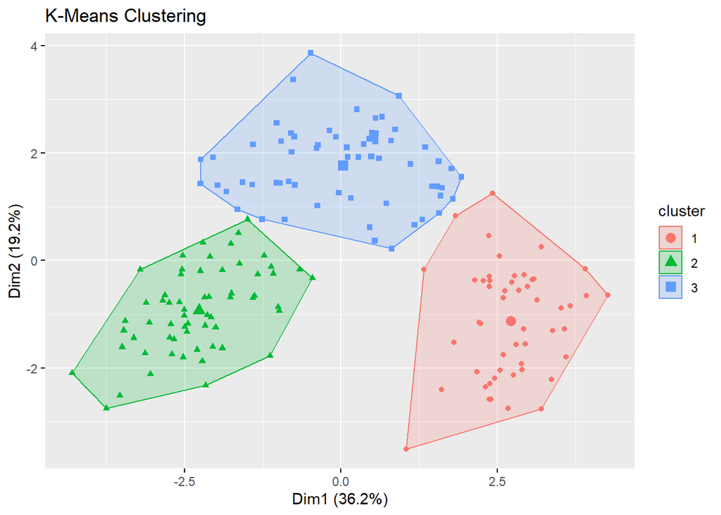

```r
set.seed(123)
kmeans_result <- kmeans(wine_scaled, centers = 3, nstart = 25)

# Visualize K-Means clusters
fviz_cluster(kmeans_result, data = wine_scaled, geom = "point", main = "K-Means Clustering")
```

```r
table(kmeans_result$cluster)
```

```
##
##  1  2  3
## 51 62 65
```

DBSCAN Clustering

[figure not shown]

```r
wss <- sapply(1:10, function(k){
  kmeans(wine_numeric, centers = k, nstart = 25)$tot.withinss
})

plot(1:10, wss, type = "b", pch = 19,
     xlab = "Number of Clusters K",
     ylab = "Total Within-Cluster Sum of Squares",
     main = "Elbow Method for K-Means")
```

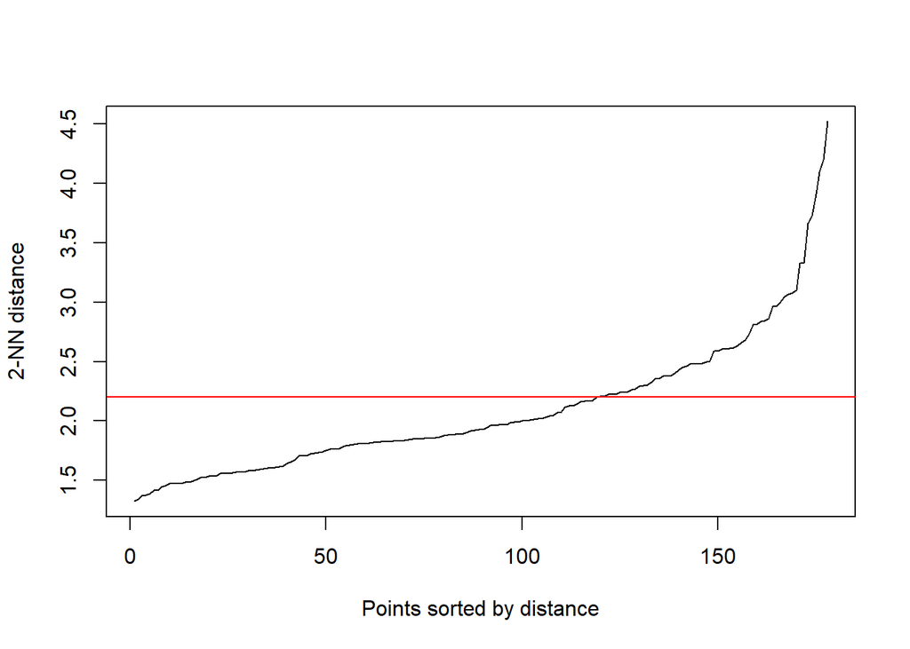

```r
# Estimate eps value visually
kNNdistplot(wine_scaled, k = 2)
abline(h = 2.2, col = "red")
```

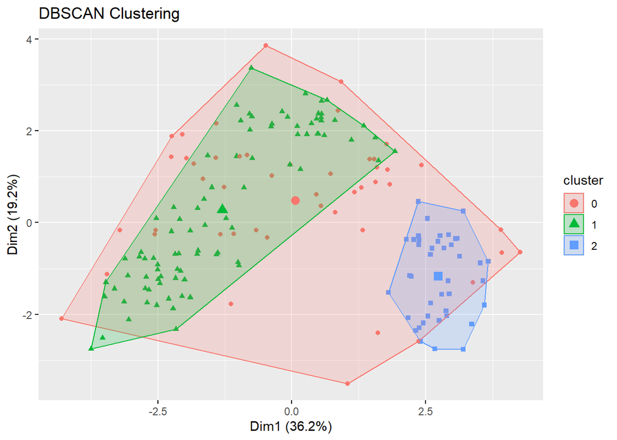

```r
dbscan_result <- dbscan(wine_scaled, eps = 2.2, minPts = 4)

fviz_cluster(list(data = wine_scaled, cluster = dbscan_result$cluster),
             geom = "point", main = "DBSCAN Clustering")
```

```r
table(dbscan_result$cluster)
```

```
##
##  0  1  2
## 48 89 41
```

[output not shown]

A. AGNES

- *Agglomerative coefficient:* ~0.94
- *Findings:* Clear, nested cluster structures formed as a result. Dendrogram provided interpretable hierarchy.
- *Suitability:* Quite useful to explore cluster hierarchy. Works well due to the fully structured and scaled numeric dataset nature.

B. DIANA

- *Divisive coefficient:* ~0.80
- *Findings:* Displayed distinct divisive tiers, yet AGNES had greater unity.
- *Suitability:* Fair. Cluster cohesion is weaker, and the dataset is numerically less optimal than AGNES.

C. K-Means

- *Eps:* 2.2 (chosen according to the kNN distance plot)
- *minPts:* 4
- *Findings:* Detected multiple clusters as well as noise. Results varied based on parameters. With tuning, there were differences. Less consistent across runs.
- *Suitability:* Useful in datasets containing many outliers or non-spherical structures. Comparatively less effective here due to similar densities.

*K-Means is largely the suitable clustering method on this wine dataset.*

The wine dataset, being fully numeric and standardized, suits distance-based clustering methods. The wine samples seem distributed evenly, with groupings corresponding to cultivars in a natural way. K-Means clustering almost produced well-separated clusters, consistent with expectations from domain knowledge. This method is computationally efficient, but it is also quite easy to interpret. K-Means is an appropriate choice for exploratory data analysis, in light of its performance as well as simplicity. It is also appropriate for practical clustering applications in production.

- AGNES provides for outstanding hierarchical understandings to its users.
- Helpful for exploring several nested relationships between wine types.
- Dendrograms are recommended to visualize cluster structures and for exploratory analysis.